# Discussion 6: T, Bootstrap and proportion Confidence intervals

Henry Mendoza Rivera, UW-Madison, Department of Statistics.

# 1 Problem 1: Situation

The mayor in City A, with 1000 households, wants to increase the city’s revenue by implementing a city-wide recycling plan. The mayor knows that the amount of recyclables in city citizens’ wastes gives a good indicator of how profitable it can be for this plan. He wants to make the right decision based on statistical evidence. The mayor asked the data analyst to find a $98\%$ estimated confidence interval of the town-wide average pounds/week for citizens from this city.

## 1.1 Step 1: Collect a simple random sample

Before collecting the sample, we need to define the sample size and the type of sampling. We need to:

1. What is the observation unit (An object on which a measurement is taken)?

Click For Answer

Each household

2. What is the target population (The complete collection of observations we want to study)?

Click For Answer

All the households in the city

3. How to construct the sample frame?

Click For Answer

The list of all households in the city can be sampled.

4. Determine the sample size. The analyst wants the least sample size satisfying $98\%$ confidence that the sample mean is within 0.01 pounds/week of the population mean. Use the formula:

$$\bbox[#ffcc99,20px,border:10px ligth red]
{
n = \left( \dfrac{z_{\alpha / 2} \sigma}{E} \right)^2
}$$

Where $z_{\alpha/2}$ is the $\frac{\alpha}{2}$th quantile of the standard normal distribution, $\sigma$ is the population standard deviation, and $E$ is the margin of error or the difference to be detected.

Assume that the standard deviation $\sigma$, was estimated with the value of the sample standard deviation from a small pilot study, $s=0.016$ pounds.

Click For Answer

- The estimated standard deviation is $s=0.016$ pounds.
- The given margin error is $E=0.01$
- The confidence level is $98\%$. Then we need to compute $z_{\alpha/2}$ using R.

```r
z<-qnorm((1-0.98)/2,mean=0,sd=1, lower.tail = FALSE)
z
```

```
## [1] 2.326348
```

- Plugin the above values, the sample size is

```r
n<-(z*0.016/0.01)^2
n
```

```
## [1] 13.85445
```

The least sample size is 14 households. The analyst decided to take n=14.

5. Explain how to select the simple random sample

Click For Answer

First, we should use the sample frame. It contains all the households with an identification number from 001-1000. Second, R software is used to select the household that will be in the sample.

```r
set.seed(1)
id<-1:1000
sample(id,size=14,replace = FALSE)
```

```
##  [1] 836 679 129 930 509 471 299 270 978 187 307 597 277 874
```

6. Explain how to collect the sample values for the defined random variable `X= The average weekly weight` of recyclable material (in pounds/week)

Click For Answer

We should visit each household selected in the sample during each week in a year and weigh the recyclable material. Then present the data in a table.

Table 1. The average weekly weight of recyclable material (in pounds/week) followed over 1 year.

[output not shown]

## 1.2 Step 2: Construct the 98% confidence interval

Construct a $98\%$ confidence interval for the town-wide average pounds/week for citizens from this city.

### 1.2.1 Check the requirements

1. Is the sample a simple random sample?

Click For Answer

Yes.

2. Is the sample from a normal distribution?

Click For Answer

- Construct the data vector in R:

```r
recycling<-c(2.8, 5.1, 10.3, 2.4, 9.0, 5.2, 2.1, 6.5, 13.4, 5.2, 5.3, 8.6, 8.9, 5.4)
```

- Make the histogram and the qqplot

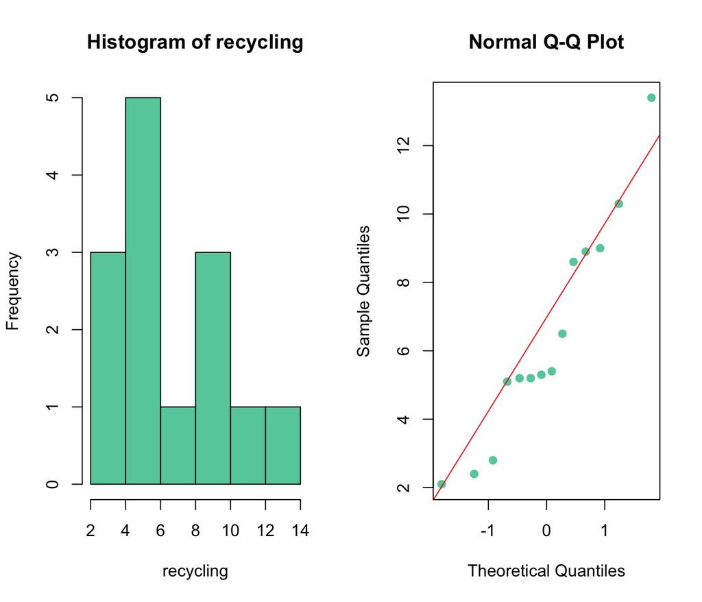

```r
par(mfrow=c(1,2))
hist(recycling,col="aquamarine3")
qqnorm(recycling,col="aquamarine3",pch = 19)
qqline(recycling,col="red")
```

The data is `slightly right-skewed`. It gives some evidence that the population `could be non-normal`, however, our sample size of 14 may be NOT large enough for the CLT to help us.

`Step 2: Determine a 98% t confidence interval`

`Stop` The assumptions are not met.

### 1.2.2 How to proceed?

#### 1.2.2.1 Determine a 98% bootstrap t confidence interval

Determine a $98\%$ bootstrap t confidence interval for the town-wide average pounds/week for citizens from this city (use set.seed(1)).

Click For Answer

Using the bootstrap code given below,

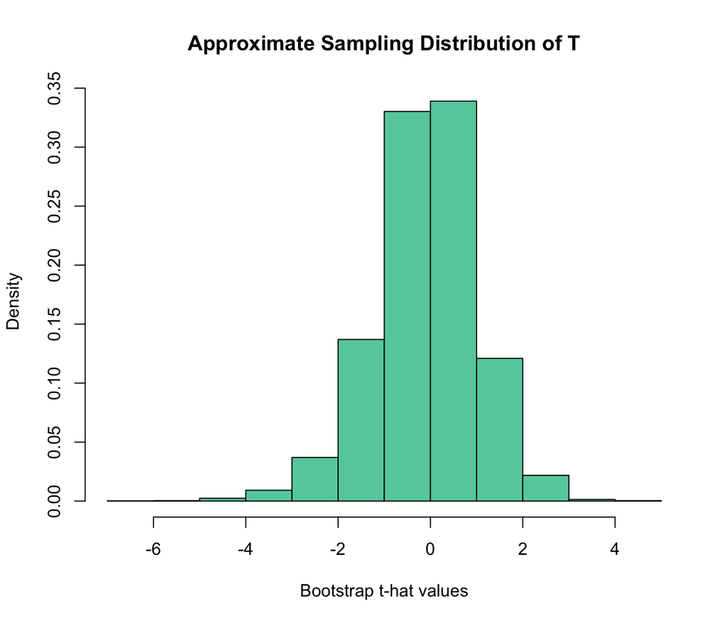

```r
#Create Bootstrap Function
bootstrap = function(x, n.boot) {
  n = length(x)
  x.bar <- mean(x)
  t.hat <- numeric(n.boot) # create vector of length n.boot zeros
  for(i in 1:n.boot) {
    x.star <- sample(x, size=n, replace=TRUE)
    x.bar.star <- mean(x.star)
    s.star <- sd(x.star)
    t.hat[i] <- (x.bar.star - x.bar) / (s.star / sqrt(n))
}
  return(t.hat)
}

#Call Bootstrap Function on our data to get bootstrap T distribution
set.seed(1)
Recycling.boot <- bootstrap(recycling, 5000)
# Plot the approximate sampling distribution.
hist(Recycling.boot, freq=FALSE, xlab = "Bootstrap t-hat values",
     main = "Approximate Sampling Distribution of T",col= "aquamarine3")
```

```r
#Find common quantiles from the bootstrap t CI
(common.quants=quantile(Recycling.boot, probs=c(0.01, 0.025, 0.05, 0.10, 0.90, 0.95, 0.975, 0.99)))
```

```
##        1%      2.5%        5%       10%       90%       95%     97.5%       99%
## -3.085530 -2.420978 -1.990834 -1.460220  1.219485  1.605464  1.969741  2.465808
```

```r
#Find quantiles from the bootstrap t CI for a 98% confidence interval.
(tboot.lower <- quantile(Recycling.boot, probs=.01)) # This is our t*_{1 - alpha.2}.
```

```
##       1%
## -3.08553
```

```r
(tboot.upper <- quantile(Recycling.boot, probs=.99)) # This is our t*_{alpha/2}.
```

```
##      99%
## 2.465808
```

```r
# Make the interval.
(n = length(recycling))
```

```
## [1] 14
```

```r
(x.bar = mean(recycling))
```

```
## [1] 6.442857
```

```r
(s = sd(recycling))
```

```
## [1] 3.23769
```

```r
(bootci.low  = x.bar - tboot.upper * s / sqrt(n)) # This is our lower interval endpoint.
```

```
##      99%
## 4.309171
```

```r
(bootci.high = x.bar - tboot.lower * s / sqrt(n)) # This is our upper interval endpoint.
```

```
##       1%
## 9.112794
```

```r
boot.interval = c(bootci.low, bootci.high)
names(boot.interval)=NULL
print(boot.interval)
```

```
## [1] 4.309171 9.112794
```

The bootstrap t interval does not use a Student t distribution as the reference distribution. Instead, the sampling distribution of a “t type” statistics (a studentized statistics) is generated by resampling.

Note

## 1.3 What if the analyst assumed normailty?

Consider that the analyst assumed normality. Obtain the $98\%$ confidence interval under this assumption, not using bootstrapping method (sample average : 6.44 and sample standard deviation: 3.24)

Click For Answer

```r
#Build standard T confidence interval
qt(.01, df=13, lower.tail=FALSE)
```

```
## [1] 2.650309
```

```r
t.test(recycling,conf.level = 0.98)
```

```
##
##  One Sample t-test
##
## data:  recycling
## t = 7.4457, df = 13, p-value = 4.864e-06
## alternative hypothesis: true mean is not equal to 0
## 98 percent confidence interval:
##  4.149521 8.736193
## sample estimates:
## mean of x
##  6.442857
```

from R: $t_{.01, 13}=2.65$ and using the summary statistics given above: $6.44 \pm 2.65*\frac{3.24}{\sqrt{14}}$=(4.15, 8.73).

## 1.4 Comparison

Comment on the similarities and differences between the assumptions that go into these two confidence intervals and the resulting computed intervals. Which interval would you recommend the city to use?

Click For Answer

For the t confidence interval, we are assuming the sample comes from a normal population, which we are not making with the bootstrap T. We see in t interval is symmetric around the sample mean (ME same in each direction), which is not the case with the bootstrap t. It depends on the assumptions that the city wants to make. The qqnorm plot of the data gives some evidence of non-linearity (and the histogram shows lack of bell curve). The bootstrap is making fewer assumptions and is wider (and thus a bit more conservative); therefore I would tend to recommend the bootstrap in this case.

# 2 Problem 2: The sample size to estimate a population proportion

A public health survey is to be designed to estimate the proportion `p` of a population having a defective vision. How many persons should be examined if the public health commissioner wishes to be $98\%$ certain that the margin of error is less than 0.05 when:

A. There is no knowledge about the value of p

Click For Answer

A $98\%$ level corresponds to a multiplier of 2.33. Since p is unknown, use .5 for p, $ME=0.05=2.33\sqrt{\frac{.5*.5}{n}}$ so $n=.5*.5(\frac{2.33}{0.05})^2=543$

```r
n=.5*.5*(2.33/0.05)^2
n
```

```
## [1] 542.89
```

B. p is known to be about 0.3

Click For Answer

$n=(.3*.7)(\frac{2.33}{0.05})^2=456$

```r
n=(.3*.7)*(2.33/0.05)^2
n
```

```
## [1] 456.0276
```

# 3 Problem 3: Confidence Interval concept review.

1. This is the equation for building a $(1-\alpha)*100\%$ large-sample Z confidence interval for $\pi$:

$$\bbox[#ffcc99,20px,border:10px ligth red]
{
\hat{p}\pm z_{\alpha/2}*\sqrt{\frac{\hat{p}*(1-\hat{p})}{n}}
}$$

2. This is the equation for building a $(1-\alpha)*100\%$ t confidence interval for $\mu$:

$$\bbox[#ffcc99,20px,border:10px ligth red]
{
\bar{x} \pm t_{\alpha/2, df}*\frac{s}{\sqrt{n}}
}$$

3. This is the equation for building a $(1-\alpha)*100\%$ bootstrap t confidence interval for $\mu$:

$$\bbox[#ffcc99,20px,border:10px ligth red]
{
(\bar{x} - t^B_{\alpha/2}*\frac{s}{\sqrt{n}}, \bar{x} - t^B_{1-\alpha/2}*\frac{s}{\sqrt{n}})
}$$

A. When would we choose to use each equation?

Click For Answer

- We should use (i) to estimate a population proportion of successes when I have an observed sample proportion of successes. A large enough sample size $n\hat{p}$ and $n(1-\hat{p})$ are both at least 5 so that the CLT tells me the distribution of $\hat{p} \approx N$.
- We should use (ii) to estimate a population mean value when I have an observed sample mean, a large enough sample size so that the CLT tells me the distribution of $\bar{X} \approx N$ considering how non-normal I believe my population to be, and I am estimating my population sd with sample sd.
- We should use (iii) to estimate a population mean value when I have an observed sample mean, and I do not want to make any normality assumptions about the population or CLT.

B. Identify the pieces of the equations that are the point estimates and which dictate the margin of error (half-width of the CI). What do the symbols in the equations stand for?

Click For Answer

- Point estimates:$\bar{x}$ sample mean, $\hat{p}$: sample proportion
- ME (quantity added/subtracted from p estimate)
- t/z/t^B multipliers come from the level of the confidence interval desired and are values in the t/z/t^(boot) distribution that has $(1-\alpha)*100\%$ of values between them; value multiplied to t/z/t^B are the approximate Standard Errors for the point estimators, i.e. how much the $\bar{x}$ and $\hat{p}$ values vary between samples.

C. What factors in the confidence interval construction will result in the most precise estimate for our population parameters? (Can use http://www.rossmanchance.com/applets/ConfSim.html to “see” the effect of changing specific characteristics)

Click For Answer

The most precise estimate for the population parameter means the narrowest interval: lower confidence level, larger sample size, smaller sample standard deviation.